# Intro to causal inference

Author

Francisco Cardozo

Published

September 29, 2022

# 1. Observational studies and propensity score ⚖️

- Conceptual stage
- Design stage
- Statistical analysis
- Summary

## Conceptual

Formulation of the causal question and assumptions using potential outcomes. Formulated as a randomized experiment.

## Design stage

Reconstruct or approximate the design of a randomized experiment (independence between treatment assignment and covariates). Needs to conduct balance diagnostic.

## Statistical analysis

Compare outcomes by treatment. This stage is similar to the standard model-based analysis.

## Summary

Conclusion based on your estimates.

# Example

```r
library(tidyverse) # data manipulation
library(skimr) # Good for descriptive analysis
library(tidymodels) # modeling
library(gt)  # To create pretty tables
library(table1) # To create pretty tables
tidymodels_prefer() # to avoid problems with two functions with the same name
```

## 1. Conceptual stage

> What is the effect of alcohol consumption on marihuana use?

### Dataset

Selected data from YRBS

```r
#load("Causal_inference/small_data.rda")
load("small_data.rda")

small_data  |> skimr::skim()
```

Data summary

| Name | small_data |
| --- | --- |
| Number of rows | 31367 |
| Number of columns | 16 |
| _______________________ |  |
| Column type frequency: |  |
| character | 2 |
| factor | 2 |
| numeric | 12 |
| ________________________ |  |
| Group variables | None |

**Variable type: character**

| skim_variable | n_missing | complete_rate | min | max | empty | n_unique | whitespace |
| --- | --- | --- | --- | --- | --- | --- | --- |
| district | 0 | 1 | 5 | 12 | 0 | 13 | 0 |
| state | 0 | 1 | 2 | 2 | 0 | 8 | 0 |

**Variable type: factor**

| skim_variable | n_missing | complete_rate | ordered | n_unique | top_counts |
| --- | --- | --- | --- | --- | --- |
| alcohol | 1718 | 0.95 | FALSE | 2 | Yes: 15746, No: 13903 |
| marijuana | 700 | 0.98 | FALSE | 2 | No: 19351, Yes: 11316 |

**Variable type: numeric**

| skim_variable | n_missing | complete_rate | mean | sd | p0 | p25 | p50 | p75 | p100 | hist |
| --- | --- | --- | --- | --- | --- | --- | --- | --- | --- | --- |
| year | 0 | 1.00 | 2018.04 | 1.00 | 2017 | 2017 | 2019 | 2019 | 2019 | ▇▁▁▁▇ |
| age | 0 | 1.00 | 5.00 | 1.23 | 1 | 4 | 5 | 6 | 7 | ▁▂▆▆▇ |
| sex | 0 | 1.00 | 0.54 | 0.50 | 0 | 0 | 1 | 1 | 1 | ▇▁▁▁▇ |
| q30 | 0 | 1.00 | 0.82 | 0.39 | 0 | 1 | 1 | 1 | 1 | ▂▁▁▁▇ |
| q50 | 0 | 1.00 | 0.03 | 0.18 | 0 | 0 | 0 | 0 | 1 | ▇▁▁▁▁ |
| q51 | 0 | 1.00 | 0.06 | 0.23 | 0 | 0 | 0 | 0 | 1 | ▇▁▁▁▁ |
| q52 | 0 | 1.00 | 0.01 | 0.12 | 0 | 0 | 0 | 0 | 1 | ▇▁▁▁▁ |
| q53 | 0 | 1.00 | 0.02 | 0.13 | 0 | 0 | 0 | 0 | 1 | ▇▁▁▁▁ |
| q54 | 0 | 1.00 | 0.03 | 0.16 | 0 | 0 | 0 | 0 | 1 | ▇▁▁▁▁ |
| q55 | 0 | 1.00 | 0.02 | 0.14 | 0 | 0 | 0 | 0 | 1 | ▇▁▁▁▁ |
| q56 | 0 | 1.00 | 0.02 | 0.13 | 0 | 0 | 0 | 0 | 1 | ▇▁▁▁▁ |
| q57 | 227 | 0.99 | 0.73 | 0.45 | 0 | 0 | 1 | 1 | 1 | ▃▁▁▁▇ |

### Demographic variables

- Age
- Sex

### Outcome

- Q46. How old were you when you tried marijuana for the first time? A. I have never tried marijuana B. 8 years old or younger C. 9 or 10 years old D. 11 or 12 years old E. 13 or 14 years old F. 15 or 16 years old G. 17 years old or older
- marijuana: recoded as 0 (never used) 1 (used)

### Alcohol use (“Treatment”)

- Q40. How old were you when you had your first drink of alcohol other than a few sips? A. I have never had a drink of alcohol other than a few sips B. 8 years old or younger C. 9 or 10 years old D. 11 or 12 years old E. 13 or 14 years old F. 15 or 16 years old G. 17 years old or older
- alcohol: recoded as 0 (never used) 1 (used)

### Questions about drug use

- Q30. Have you ever tried cigarette smoking, even one or two puffs?
- Q50. During your life, how many times have you used any form of cocaine, including powder, crack, or freebase?
- Q51. During your life, how many times have you sniffed glue, breathed the contents of aerosol spray cans, or inhaled any paints or sprays to get high?
- Q52. During your life, how many times have you used heroin (also called smack, junk, or China White)?
- Q53. During your life, how many times have you used methamphetamines (also called speed, crystal meth, crank, ice, or meth)?
- Q54. During your life, how many times have you used ecstasy (also called MDMA)?
- Q55. During your life, how many times have you taken steroid pills or shots without a doctor’s prescription?
- Q56. During your life, how many times have you used a needle to inject any illegal drug into your body?
- Q57. During the past 12 months, has anyone offered, sold, or given you an illegal drug on school property?

### Filter by year

```r
data_2019 <- small_data %>%
  filter(year==2019) %>%
  select(-district, -state)
```

## 2. Design stage (A)

### Balance diagnostic

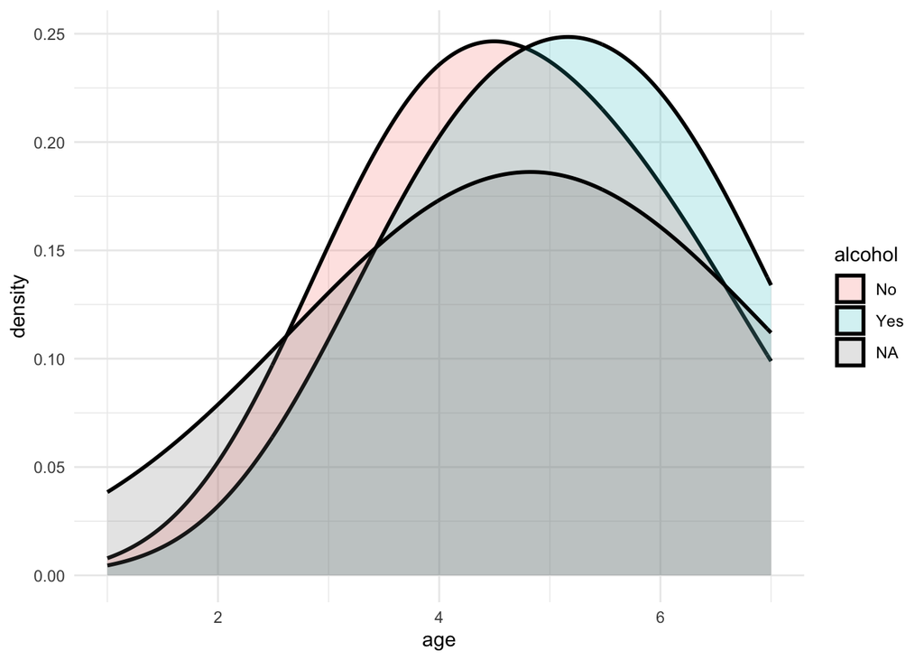

```r
data_2019 %>%
  ggplot(aes(age,
             fill=alcohol)) +
  geom_density(size=1, adjust=5, alpha=0.2) +
  theme_minimal()
```

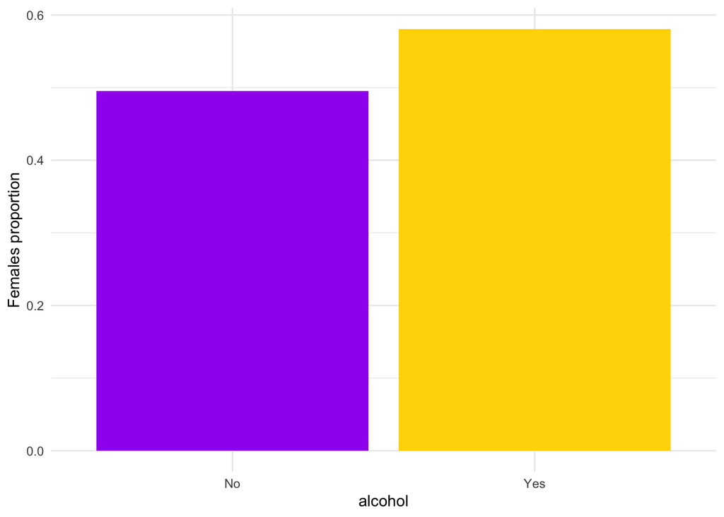

```r
data_2019 %>%
  filter(!is.na(alcohol)) %>%
  mutate(sex=if_else(sex==1,1,0)) %>%
  group_by(alcohol) %>%
  summarise(`Females proportion`=
              mean(as.numeric(as.character(sex)), na.rm=T)) %>%
  ggplot(aes(alcohol, `Females proportion`, fill=alcohol)) +
  geom_bar(stat="identity") +
  theme_minimal() +
  theme(legend.position = "none") +
  scale_fill_manual(values = c("purple", "gold"))
```

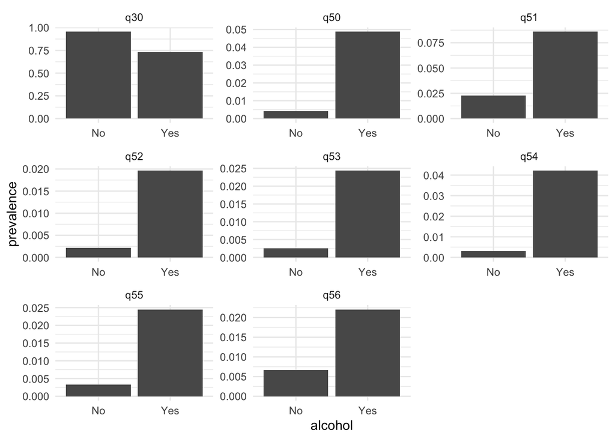

```r
data_2019 %>%
  select(c("alcohol",  "q30", "q50", "q51","q52",
           "q53", "q54", "q55", "q56")) %>%
  filter(!is.na(alcohol)) %>%
  pivot_longer(cols=-alcohol,
               names_to = "Drugs",
               values_to="Use" ) %>%
  group_by(alcohol, Drugs) %>%
  summarise(prevalence=mean(Use, na.rm=T)) %>%
  ggplot(aes(alcohol, prevalence)) +
  geom_bar(stat="identity") +
  facet_wrap(~ Drugs, scales = "free") +
  theme_minimal()
```

```r
data_2019 %>%
  filter(!is.na(alcohol)) %>%
  select(c("alcohol",  "q30", "q50", "q51","q52",
           "q53", "q54", "q55", "q56")) %>%
  mutate(id=row_number()) %>%
  pivot_longer(cols=-c(alcohol,id),
               names_to = "Drugs",
               values_to="Use" ) %>%
  group_by(id, alcohol) %>%
  summarise(sum=sum(as.numeric(Use), na.rm = T)) %>%
  ungroup() %>%
  count(alcohol, sum) %>%
  pivot_wider(names_from = sum, values_from = n) %>%
  gt() %>%
  tab_header(
    title = "Number of substances")
```

Number of substances

| alcohol | 0 | 1 | 2 | 3 | 4 | 5 | 7 | 6 | 8 |
| --- | --- | --- | --- | --- | --- | --- | --- | --- | --- |
| No | 285 | 6980 | 211 | 21 | 5 | 5 | 1 | NA | NA |
| Yes | 1585 | 5782 | 603 | 106 | 45 | 39 | 38 | 37 | 6 |

## 2. Design stage (B)

### Hypothetical scenario 1

*No design; use all the information 0 and 1.*

Complete randomized experiment. In the beginning, everyone was drinking, but we implemented an intervention to make them stop drinking with a 1/2 probability. Then, we observed the use of marijuana in both groups.

### Hypothetical scenario 2

*Trimming for the number of drugs.*

Students who used more than three drugs were dropped from the analysis because there were not enough participants in the control group with that number of drugs used.

### Hypothetical scenario 3

*Block or stratified randomized experiments.*

Females and males were randomized into two different groups.

### Hypothetical scenario 4

*Propensity score, IPW, and caliper.*

A completely randomized experiment with balanced groups. The balance between groups is achieved via inverse probability weighting (or matching or a caliper).

### Hypothetical scenario 5

*Randomized experiment controlling by base-line use of marijuana*

Students who have not used marijuana are intervened to stop using alcohol with a probability of 1/2. Then we compared marijuana initiation in students who continued drinking alcohol to those who stopped.

## 3. Analysis

Compare the outcomes of interest in the exposed versus non-exposed units of the hypothetical randomized experiment.

We will estimate hypothetical scenario 1 and 4.

### Hypothetical scenario 1

No design. Use all units available.

```r
glm(marijuana ~ alcohol,
    data=data_2019,
    family = "binomial") %>%
  tidy(exp=T, conf.int=T)
```

```
# A tibble: 2 × 7
  term        estimate std.error statistic p.value conf.low conf.high
  <chr>          <dbl>     <dbl>     <dbl>   <dbl>    <dbl>     <dbl>
1 (Intercept)    0.146    0.0348     -55.2       0    0.136     0.156
2 alcoholYes    10.4      0.0416      56.3       0    9.61     11.3
```

### Hypothetical scenario 4

**Inverse Probability Weighting (IPW)**

Estimates two different models:

- Model to compute propensity score.
- Model to estimate the effect.

### Estimate propensity score

What engine do we want to use?

```r
logistic <- logistic_reg() %>%
        set_engine("glm") %>%
        set_mode("classification")
```

What is the formula?

```r
formula_ps <- recipe(alcohol ~ age + sex +q30 +
              q50 + q51 + q52 + q53 + q54+
              q55 + q56 + q57, data = data_2019)
```

Combine the engine and formula in a workflow

```r
treatment_wflow <-
  workflow() |>
  add_recipe(formula_ps) |>
  add_model(logistic)
```

Estimate the model

```r
fit(treatment_wflow, data=data_2019) |>
  tidy(conf.int=TRUE)
```

```
# A tibble: 12 × 7
   term        estimate std.error statistic   p.value conf.low conf.high
   <chr>          <dbl>     <dbl>     <dbl>     <dbl>    <dbl>     <dbl>
 1 (Intercept)   0.674     0.100     6.73   1.73e- 11    0.478     0.871
 2 age           0.243     0.0145   16.7    7.79e- 63    0.215     0.271
 3 sex           0.470     0.0351   13.4    7.97e- 41    0.401     0.539
 4 q30          -1.84      0.0639  -28.8    5.11e-183   -1.97     -1.72
 5 q50           1.12      0.211     5.33   9.69e-  8    0.724     1.55
 6 q51           0.963     0.0954   10.1    6.27e- 24    0.778     1.15
 7 q52          -0.0321    0.348    -0.0921 9.27e-  1   -0.702     0.671
 8 q53           0.244     0.319     0.766  4.44e-  1   -0.366     0.887
 9 q54           1.17      0.235     4.99   6.10e-  7    0.729     1.65
10 q55           0.754     0.258     2.92   3.45e-  3    0.263     1.28
11 q56          -0.134     0.220    -0.610  5.42e-  1   -0.565     0.299
12 q57          -0.695     0.0404  -17.2    2.38e- 66   -0.774    -0.616
```

Save the results of your model

```r
treatment_results <- fit(treatment_wflow, data=data_2019)
```

Plot the model results

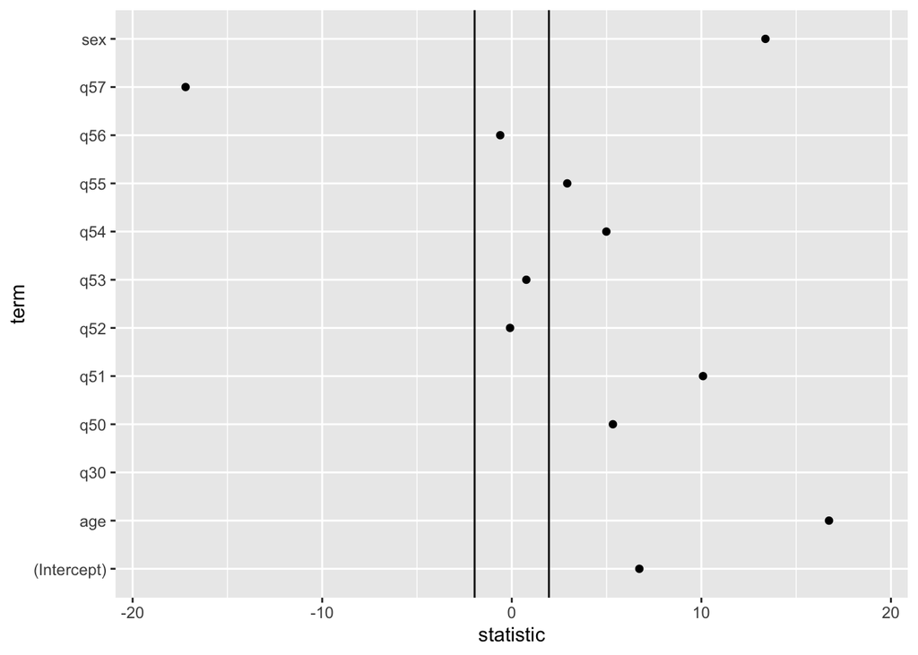

```r
to_plot <- fit(treatment_wflow, data=data_2019) |>
  tidy(conf.int=TRUE)

ggplot(to_plot, aes(statistic, term)) +
  geom_point() +
  xlim(c(-19,19)) +
  geom_vline(xintercept = c(1.96,-1.96))
```

Next, estimate the propensity score

- Estimate the probability of receiving treatment given the covariates
- Combine observed and estimated data (merge by ID)

```r
to_ipw <- predict(treatment_results, new_data = data_2019, type="prob")

to_ipw <- bind_cols(to_ipw, data_2019) %>% select(.pred_Yes, alcohol, everything())

head(to_ipw)
```

```
# A tibble: 6 × 16
  .pred_Yes alcohol .pred_No  year age         sex   q30   q50   q51   q52   q53
      <dbl> <fct>      <dbl> <dbl> <dbl+lbl> <dbl> <dbl> <dbl> <dbl> <dbl> <dbl>
1     0.896 <NA>       0.104  2019 1 [12 ye…     0     0     0     1     1     1
2     0.392 No         0.608  2019 3 [14 ye…     0     1     0     0     0     0
3     0.628 Yes        0.372  2019 3 [14 ye…     0     1     0     1     0     0
4     0.457 No         0.543  2019 3 [14 ye…     0     1     0     1     0     0
5     0.392 No         0.608  2019 3 [14 ye…     0     1     0     0     0     0
6     0.243 No         0.757  2019 3 [14 ye…     0     1     0     0     0     0
# ℹ 5 more variables: q54 <dbl>, q55 <dbl>, q56 <dbl>, q57 <dbl>,
#   marijuana <fct>
```

Check for the area of common support

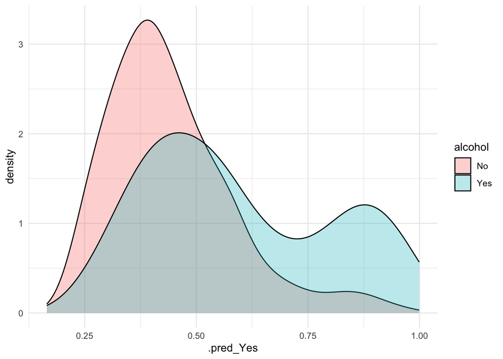

```r
to_ipw |>
  filter(!is.na(alcohol)) |>
  filter(!is.na(.pred_Yes)) |>
  group_by(alcohol) |>
  ggplot(aes(.pred_Yes, fill=alcohol)) +
  geom_density(adjust = 2, alpha=0.3) +
  theme_minimal()
```

Trim your data set

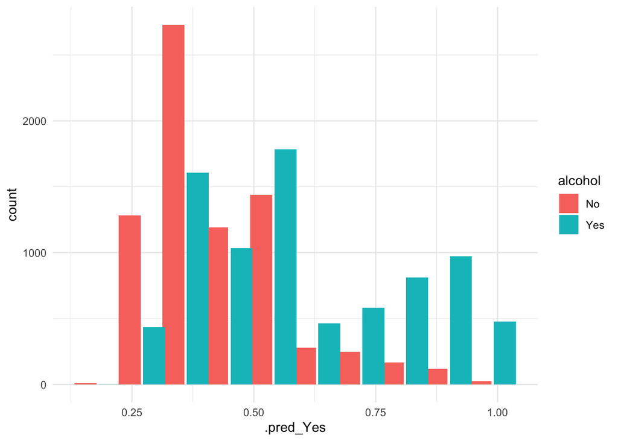

```r
to_ipw |> filter(!is.na(alcohol)) |>
  filter(!is.na(.pred_Yes)) |>
  ggplot(aes(.pred_Yes, fill=alcohol)) +
  geom_histogram(position = position_dodge(width = 0.1), binwidth = 0.09) +
  theme_minimal()
```

```r
to_ipw %>% table1(~ .pred_Yes | alcohol, data=.)
```

|  | No (N=7508) | Yes (N=8241) | Overall (N=16242) |
| --- | --- | --- | --- |
| .pred_Yes |  |  |  |
| Mean (SD) | 0.442 (0.141) | 0.595 (0.208) | 0.523 (0.196) |
| Median [Min, Max] | 0.400 [0.165, 0.993] | 0.568 [0.201, 0.999] | 0.459 [0.165, 0.999] |
| Missing | 18 (0.2%) | 68 (0.8%) | 107 (0.7%) |

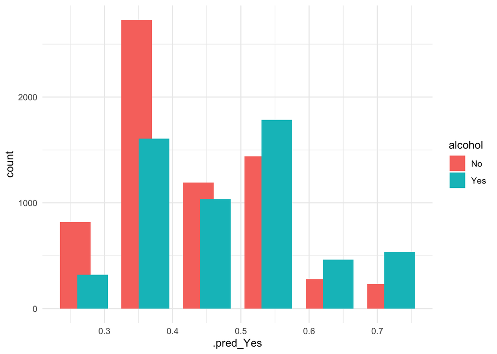

```r
to_ipw <-
to_ipw %>%
  filter(.pred_Yes > 0.25) %>%
  filter(.pred_Yes < 0.75)

to_ipw %>%  filter(!is.na(alcohol)) |>
  filter(!is.na(.pred_Yes)) |>
  ggplot(aes(.pred_Yes, fill=alcohol)) +
  geom_histogram(position = position_dodge(width = 0.05), binwidth = 0.09) +
  theme_minimal()
```

Compute observation weights

```r
data_ipw <-
  to_ipw |>
  mutate(
    ipw = case_when(
      alcohol == "Yes" ~ 1 / .pred_Yes,
      alcohol == "No" ~ 1 / (1 - .pred_Yes)
    ),
    ipw = importance_weights(ipw)
  ) |>
  select(ipw, alcohol, marijuana, everything())
```

### Check for balance between groups

```r
ipw_test_recipe <- recipe(alcohol ~ age + sex +
                            q30 + q50 + q51 + q52 + q53 + q54+
                            q55 + q56 + ipw, data = data_ipw)



ipw_test_wflow <-
  workflow() |>
  add_case_weights(ipw) |>
  add_recipe(ipw_test_recipe) |>
  add_model(logistic)

fit(ipw_test_wflow, data = data_ipw) |>
  tidy()
```

```
# A tibble: 11 × 5
   term        estimate std.error statistic p.value
   <chr>          <dbl>     <dbl>     <dbl>   <dbl>
 1 (Intercept)  0.139      0.120    1.16     0.244
 2 age         -0.00765    0.0111  -0.691    0.489
 3 sex         -0.0232     0.0260  -0.891    0.373
 4 q30         -0.0879     0.115   -0.764    0.445
 5 q50          0.474      0.237    2.00     0.0458
 6 q51          0.0631     0.0767   0.822    0.411
 7 q52          0.522      0.334    1.56     0.118
 8 q53         -0.00159    0.289   -0.00551  0.996
 9 q54          0.463      0.296    1.57     0.117
10 q55          0.433      0.227    1.91     0.0563
11 q56         -0.0608     0.172   -0.354    0.724
```

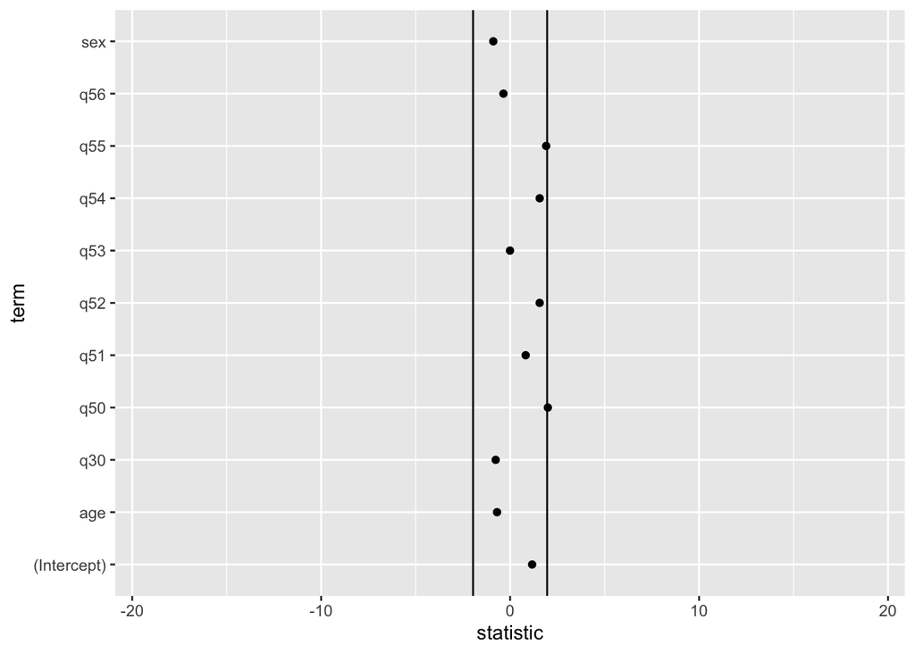

```r
to_plot_test_ipw <- fit(ipw_test_wflow, data = data_ipw) |>
  tidy()

ggplot(to_plot_test_ipw, aes(statistic, term)) +
  geom_point() +
  xlim(c(-19,19)) +
  geom_vline(xintercept = c(1.96,-1.96))
```

### Fit the model to answer the question

```r
finaldata <- data_ipw |>
  select(marijuana, alcohol, ipw)


causal_effect_recipe <-
  recipe(marijuana ~ .,
         data = finaldata)

causal_effect_wflow <-
  workflow() |>
  add_case_weights(ipw) |>
  add_recipe(causal_effect_recipe) |>
  add_model(logistic)

fit(causal_effect_wflow, data = finaldata) |>
  tidy(exp=TRUE, conf.int=TRUE)
```

```
# A tibble: 2 × 7
  term        estimate std.error statistic p.value conf.low conf.high
  <chr>          <dbl>     <dbl>     <dbl>   <dbl>    <dbl>     <dbl>
1 (Intercept)    0.144    0.0272     -71.2       0    0.137     0.152
2 alcoholYes     7.06     0.0326      59.9       0    6.63      7.53
```

If you want, compare to a model with controls.

```r
glm(marijuana ~ alcohol + age + sex +q30 + q50 + q51 + q52 +
         q53 + q54 + q55 + q56, data = data_ipw, family = binomial) %>%
  tidy(exp=T)
```

```
# A tibble: 12 × 5
   term        estimate std.error statistic  p.value
   <chr>          <dbl>     <dbl>     <dbl>    <dbl>
 1 (Intercept)    0.145    0.196     -9.85  7.11e-23
 2 alcoholYes     7.86     0.0471    43.7   0
 3 age            1.23     0.0194    10.8   4.94e-27
 4 sex            1.08     0.0456     1.69  9.18e- 2
 5 q30            0.302    0.185     -6.46  1.03e-10
 6 q50            3.63     0.376      3.43  6.14e- 4
 7 q51            1.32     0.123      2.28  2.29e- 2
 8 q52            1.44     0.531      0.693 4.88e- 1
 9 q53            2.20     0.520      1.51  1.30e- 1
10 q54            7.56     0.548      3.69  2.20e- 4
11 q55            0.684    0.372     -1.02  3.07e- 1
12 q56            1.72     0.285      1.90  5.71e- 2
```

What is the difference between IPW and the controlled model?

### Prevalence of marijuana and alcohol

```r
library(table1)
data_2019 %>%
  select(alcohol, marijuana) %>%
  table1(~alcohol | marijuana, data = .)
```

|  | No (N=9943) | Yes (N=5936) | Overall (N=16242) |
| --- | --- | --- | --- |
| alcohol |  |  |  |
| No | 6471 (65.1%) | 946 (15.9%) | 7508 (46.2%) |
| Yes | 3189 (32.1%) | 4859 (81.9%) | 8241 (50.7%) |
| Missing | 283 (2.8%) | 131 (2.2%) | 493 (3.0%) |

```r
data_2019 %>%
  select(alcohol, marijuana) %>%
  table1(~marijuana | alcohol, data = .)
```

|  | No (N=7508) | Yes (N=8241) | Overall (N=16242) |
| --- | --- | --- | --- |
| marijuana |  |  |  |
| No | 6471 (86.2%) | 3189 (38.7%) | 9943 (61.2%) |
| Yes | 946 (12.6%) | 4859 (59.0%) | 5936 (36.5%) |
| Missing | 91 (1.2%) | 193 (2.3%) | 363 (2.2%) |

# 2. Differences in differences 🔀

- To evaluate the mean change after the implementation of an intervention.
- Estimate the counterfactual based on a comparison group.

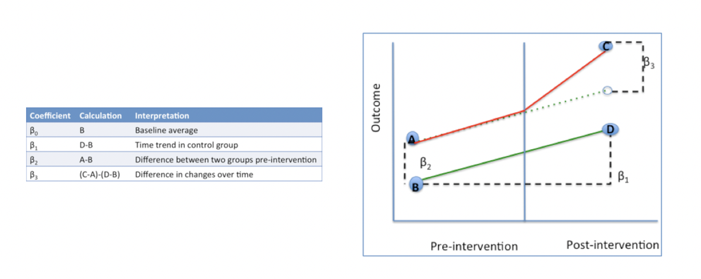

https://www.publichealth.columbia.edu/research/population-health-methods/difference-difference-estimation

## Example

Using the YRBS data, estimate the effect of marijuana legalization on marijuana use in adolescents.

> What is the effect of marijuana legalization on the use of marijuana?

Define a control group. Choose the best control group.

Timeline of marijuana policy reform in California

2016: Voters approved a ballot initiative legalizing marijuana for adults and establishing a regulated marijuana market.

2017: Licensing and regulatory system for medical marijuana businesses are paired with a similar regulatory system being developed for non-medical, now under one agency.

2018: First legal sales for adult consumers began!

from: https://www.mpp.org/states/california/

The comparison group will be Florida.

from: https://www.nytimes.com/interactive/2018/04/03/upshot/what-is-your-citys-twin.html

```r
diff_diff <- small_data %>%
  mutate(marijuana=factor(marijuana)) %>%
  mutate(nmarijuana=case_when(marijuana=="Yes" ~ 1,
                              marijuana=="No" ~ 0)) %>%
  select(state, year, marijuana, nmarijuana) %>%
  filter( state=="FL" |
         state=="CA") %>%
  filter(year>=2017)

head(diff_diff)
```

```
# A tibble: 6 × 4
  state  year marijuana nmarijuana
  <chr> <dbl> <fct>          <dbl>
1 FL     2017 <NA>              NA
2 FL     2017 <NA>              NA
3 FL     2017 No                 0
4 FL     2017 No                 0
5 FL     2017 Yes                1
6 FL     2017 No                 0
```

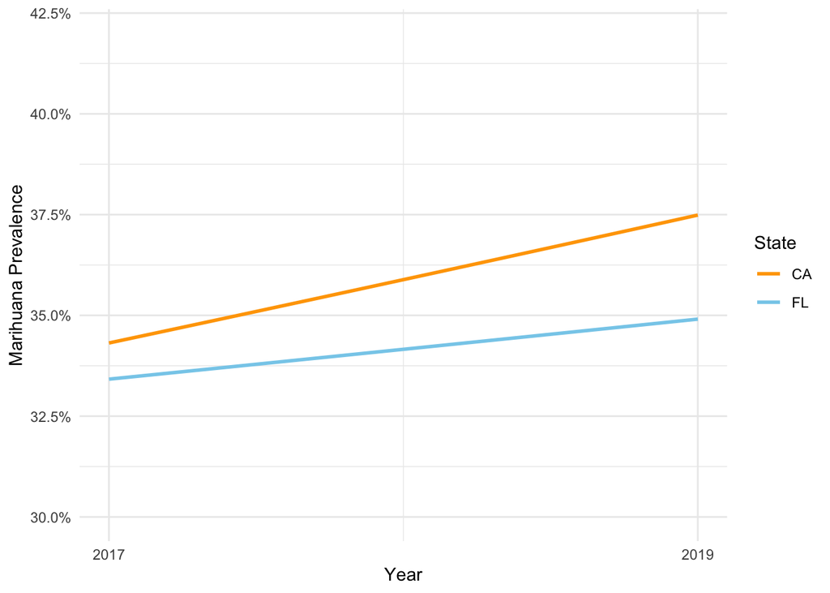

```r
diff_diff %>%
  ggplot(aes(x=year, y=nmarijuana, color=state, group=state)) +
  geom_smooth(method = "glm", method.args = list(family = "binomial"), se=F) +
  coord_cartesian(ylim = c(0.3,0.42)) +
  theme_minimal() +
  labs(y="Marihuana Prevalence", x="Year", color="State") +
  scale_x_continuous(breaks = c(2017, 2019)) +
  scale_y_continuous(labels = scales::"percent") +
  scale_color_manual(values=c("orange", "skyblue"))
```

### Organize the data

```r
diff_diff2 <-
  diff_diff %>%
  filter(!is.na(marijuana)) %>%
  mutate(treatment = case_when(
    state == "CA" ~ 1,
    state != "CA" ~ 0
  )) %>%
  mutate(year = year - 2017) %>%
  mutate(interaction = treatment * year)

head(diff_diff2)
```

```
# A tibble: 6 × 6
  state  year marijuana nmarijuana treatment interaction
  <chr> <dbl> <fct>          <dbl>     <dbl>       <dbl>
1 FL        0 No                 0         0           0
2 FL        0 No                 0         0           0
3 FL        0 Yes                1         0           0
4 FL        0 No                 0         0           0
5 FL        0 No                 0         0           0
6 FL        0 Yes                1         0           0
```

### Estimate the regression

Choose the engine

```r
logistic <- logistic_reg() %>%
        set_engine("glm") %>%
        set_mode("classification")
```

### The formula

[Click here](https://jamboard.google.com/d/14Wrq0iFfAFk-CIIilw3dGRQWIJ54WHWsYzs9YeysoXk/edit?usp=sharing)

```r
formula_did <- recipe(marijuana ~ year + treatment + interaction, data = diff_diff2)
```

### Estimation

```r
did_wflow <-
  workflow() |>
  add_recipe(formula_did) |>
  add_model(logistic)

fit(did_wflow, data=diff_diff2) |>
  tidy(conf.int=TRUE, exp=T)
```

```
# A tibble: 4 × 7
  term        estimate std.error statistic   p.value conf.low conf.high
  <chr>          <dbl>     <dbl>     <dbl>     <dbl>    <dbl>     <dbl>
1 (Intercept)    0.502    0.0267   -25.8   1.02e-146    0.476     0.529
2 year           1.03     0.0183     1.81  7.03e-  2    0.997     1.07
3 treatment      1.04     0.0652     0.615 5.39e-  1    0.916     1.18
4 interaction    1.04     0.0468     0.767 4.43e-  1    0.946     1.14
```

```r
did_results <- fit(did_wflow, data=diff_diff2)
```

### Recover the prevalences from the model

```r
to_predict <- as.data.frame(tibble(year=c(0,0,2,2),
       treatment=c(1,0,1,0),
      interaction=c(0,0,1,1)))
```

```r
predict(did_results, new_data = to_predict, type="prob")
```

```
# A tibble: 4 × 2
  .pred_No .pred_Yes
     <dbl>     <dbl>
1    0.657     0.343
2    0.666     0.334
3    0.633     0.367
4    0.643     0.357
```

### Estimate the means for each group

```r
diff_diff2 %>% group_by(treatment, year) %>%
  summarise(mean=mean(nmarijuana, na.rm=T)) %>%
  ungroup() %>%
  pivot_wider(names_from=year, values_from=mean)
```

```
# A tibble: 2 × 3
  treatment   `0`   `2`
      <dbl> <dbl> <dbl>
1         0 0.334 0.349
2         1 0.343 0.375
```

# Reference

Bind, M.-A. C., & Rubin, D. B. (2019). Bridging observational studies and randomized experiments by embedding the former in the latter. Statistical Methods in Medical Research, 28(7), 1958–1978. https://doi.org/10.1177/0962280217740609